# Taller ecuciones diferenciales

Valores para a,b,c y w a=-4 b=1/5 c=10.45 w=sqrt(3)-> raiz de 3

Punto 1. Resolver el problema de valor inicial, utilizando el método de Runge-Kutta de orden tres y de orden cuatro, obtenga: a. 20 puntos de la solución con h = 0.1 y h = 0.2, b. Encuentre los errores locales y el error global. c. Realice una gráfica que compare la solución del aproximada con la exacta, para la ecuación: X’‘− aX − X’= 0; X(0) = 2, X’(0) = −1

```r
rm(list=ls())
require(deSolve)
require(PolynomF)
require(Matrix)
options(digits = 4)
funcionReal<-function(x){
  yR <- (2/15)*exp(x/2)*(15*cos((sqrt(15)*x)/2)-2*sqrt(15)*sin((sqrt(15)*x)/2))
  return(yR)
}
funcion=function(t,y,parms){
  dy <- y[2]
  dz <- -4*y[1]+y[2]
  return(list(c(dy,dz)))
}
tis = seq(0,2,by = 0.1)
yR = funcionReal(tis)
plot(tis,yR,pch = 15, col = "red", cex = 1, xlim = c(0, 2), ylim = c(-10, 5), xlab = "x", ylab = "y",main = "x''-x-x'=0 con h = 0,1")
par(new = TRUE)
```

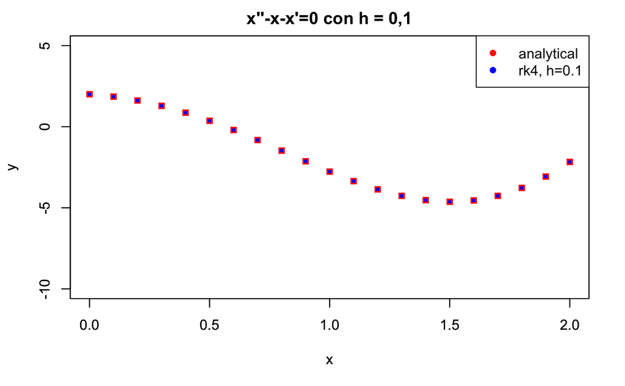

```r
sol = ode(c(2,-1),tis,funcion,parms=NULL,method = "rk4")
tabla = data.frame(sol)
plot(tis,tabla[,2], pch = 15, col = "blue", cex = 0.5,xlim = c(0, 2), ylim = c(-10, 5), xlab = "x", ylab = "y")
legend("topright",
       c("analytical","rk4, h=0.1"),
       lty = c(NA, NA), lwd = c(2, 1),
       pch = c(16, 16),
       col = c("red", "blue"))
```

```r
error <- (yR-tabla[,2])/tabla[,2]
tablaError = data.frame(tis, round(yR, digits = 5),round(tabla[,2], digits = 5),round(error, digits = 5))
colnames(tablaError) <- c("x","y","y(RK4)","Error")
tablaError
```

| x | y | y(RK4) | Error |
| --- | --- | --- | --- |
| 0.0 | 2.0000 | 2.0000 | 0e+00 |
| 0.1 | 1.8543 | 1.8543 | 0e+00 |
| 0.2 | 1.6155 | 1.6155 | 0e+00 |
| 0.3 | 1.2839 | 1.2839 | 1e-05 |
| 0.4 | 0.8636 | 0.8636 | 1e-05 |
| 0.5 | 0.3628 | 0.3628 | 0e+00 |
| 0.6 | -0.2058 | -0.2058 | 5e-05 |
| 0.7 | -0.8256 | -0.8256 | 3e-05 |
| 0.8 | -1.4759 | -1.4759 | 3e-05 |
| 0.9 | -2.1328 | -2.1328 | 3e-05 |

[output cut: 11 more lines]

```r
errorGlobal <- sum(error)/length(error)
errorGlobal
```

```
[1] 2.49e-05
```

```r
#con h=0,2
rm(list=ls())
funcionReal<-function(x){
  yR <- (2/15)*exp(x/2)*(15*cos((sqrt(15)*x)/2)-2*sqrt(15)*sin((sqrt(15)*x)/2))
  return(yR)
}
funcion=function(t,y,parms){
  dy <- y[2]
  dz <- -4*y[1]+y[2]
  return(list(c(dy,dz)))
}
tis = seq(0,4,by = 0.2)
yR = funcionReal(tis)
plot(tis,yR,pch = 15, col = "red", cex = 1, xlim = c(0, 4), ylim = c(-20, 5), xlab = "x", ylab = "y", main = "x''-x-x'=0 con h = 0,2")
par(new = TRUE)
```

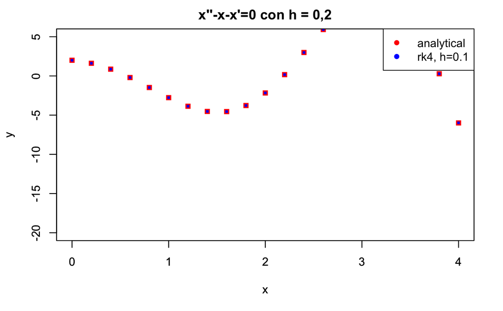

```r
sol = ode(c(2,-1),tis,funcion,parms=NULL,method = "rk4")
tabla = data.frame(sol)
plot(tis,tabla[,2], pch = 15, col = "blue", cex = 0.5,xlim = c(0, 4), ylim = c(-20, 5), xlab = "x", ylab = "y")
legend("topright",
       c("analytical","rk4, h=0.1"),
       lty = c(NA, NA), lwd = c(2, 1),
       pch = c(16, 16),
       col = c("red", "blue"))
```

```r
error <- (yR-tabla[,2])/tabla[,2]
tablaError = data.frame(tis, round(yR, digits = 5),round(tabla[,2], digits = 5),round(error, digits = 5))
colnames(tablaError) <- c("x","y","y(RK4)","Error")
tablaError
```

| x | y | y(RK4) | Error |
| --- | --- | --- | --- |
| 0.0 | 2.0000 | 2.0000 | 0.00000 |
| 0.2 | 1.6155 | 1.6154 | 0.00008 |
| 0.4 | 0.8636 | 0.8634 | 0.00016 |
| 0.6 | -0.2058 | -0.2057 | 0.00018 |
| 0.8 | -1.4759 | -1.4755 | 0.00030 |
| 1.0 | -2.7694 | -2.7683 | 0.00039 |
| 1.2 | -3.8651 | -3.8633 | 0.00047 |
| 1.4 | -4.5280 | -4.5255 | 0.00055 |
| 1.6 | -4.5462 | -4.5433 | 0.00063 |
| 1.8 | -3.7739 | -3.7712 | 0.00072 |

[output cut: 11 more lines]

```r
errorGlobal <- sum(error)/length(error)
errorGlobal
```

```
[1] 0.0008133
```

```r
exacta<- function (x) (2/15)*exp(x/2)*(15*cos((sqrt(15)*x)/2)-2*sqrt(15)*sin((sqrt(15)*x)/2))
```

Punto 2. Encuentre los 10 puntos de la solución del siguiente problema de valor inicial. a. Utilice el método de Euler mejorado. b.Grafique los errores locales y globales y comparelos y determine su orden de convergencia

```
        t        y
 [1,] 3.0 6.000000
 [2,] 3.1 5.100000
 [3,] 3.2 4.610000
 [4,] 3.3 4.366000
 [5,] 3.4 4.269600
 [6,] 3.5 4.261760
 [7,] 3.6 4.307056
 [8,] 3.7 4.384234
 [9,] 3.8 4.480540
[10,] 3.9 4.588324
        t         x
 [1,] 3.0  3.000000
 [2,] 3.1  3.840000
 [3,] 3.2  4.693200
 [4,] 3.3  5.559336
 [5,] 3.4  6.438149
 [6,] 3.5  7.329386
 [7,] 3.6  8.232799
 [8,] 3.7  9.148143
 [9,] 3.8 10.075180
[10,] 3.9 11.013676
```

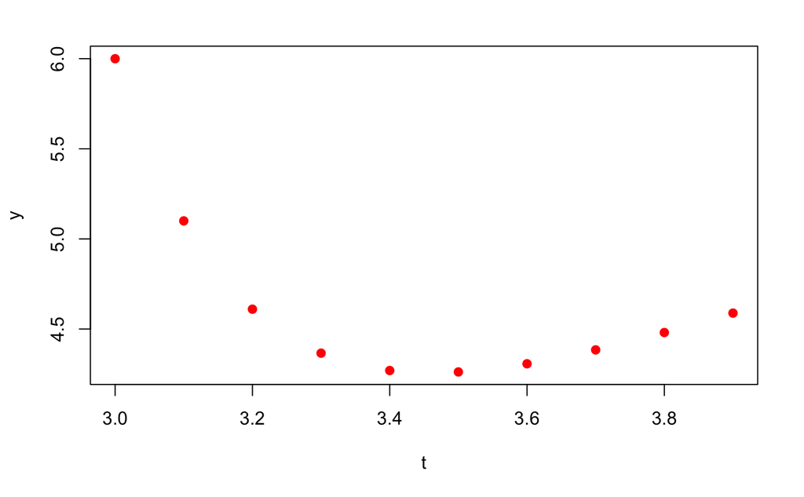

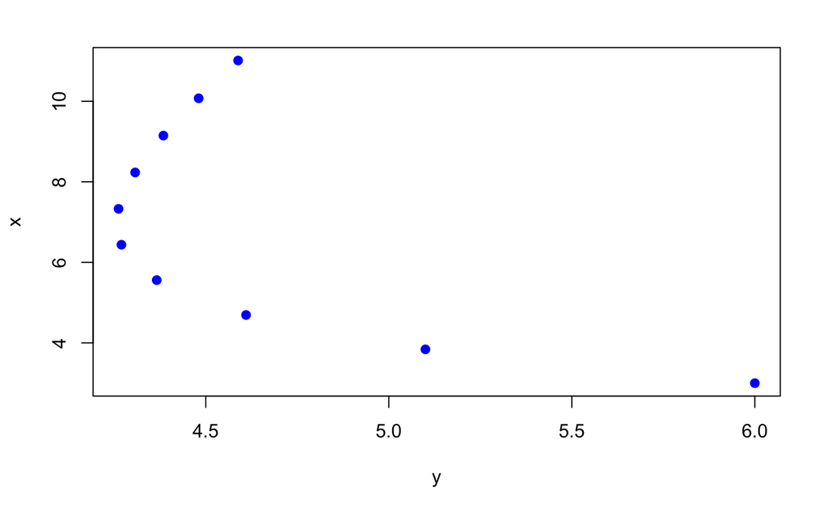

```r
euler1 = function(f,f2,t0, y0, h, n) {
#Datos igualmente espaciados iniciando en x0 = a, paso h. "n" datos
  t = seq(t0, t0 + (n-1)*h, by = h) # n datos
y = rep(NA, times=n) # n datos
y[1]=y0
x = rep(NA, times=n) # n datos
x[1]=t0
for(i in 2:n ) x[i]= x[i-1]+h*f(t[i-1], x[i-1])
for(i in 2:n ) y[i]= y[i-1]+h*f2(t[i-1], y[i-1])
print(cbind(t,y)) # print
plot(t,y, pch=19, col="red") # gráfica
print (cbind(t,x))
plot(y,x,pch=19, col="blue")
}
xprima = function(x,y) 3*x-0.2*y
yprima <- function(x,y) 5*x-4*y
n=10
x0=3
y0=6
h=0.1
euler1(xprima,yprima,x0, y0,h,n)
```

Punto 3. Solucionar la siguiente ecuación utilice el métdo de Runge-Kutta de cuarto orden con h = 0.1, grafique la solución, obtenga 20 puntos de la solución Y’‘− Y’− X + Y + 1 = 0; Y (0) = 1; Y’(0) = 2

```r
rm(list=ls())
require(deSolve)
require(PolynomF)
require(Matrix)
options(digits = 5)
rm(list=ls())
funcionReal<-function(x){
  yR <- x + (exp(x/2)*sin((sqrt(3)*x)/2))/sqrt(3) + exp(x/2)*cos((sqrt(3)*x)/2)
  return(yR)
}
funcion=function(t,y,parms){
  dy <- y[2]
  dz <- y[2]+t-y[1]-1
  return(list(c(dy,dz)))
}
tis = seq(0,2,by = 0.1)
yR = funcionReal(tis)
plot(tis,yR,pch = 15, col = "red", cex = 1, xlim = c(0, 3), ylim = c(0, 5), xlab = "x", ylab = "y", main = "y''- y'- x + y +1 =0 con h = 0,1")
par(new = TRUE)
```

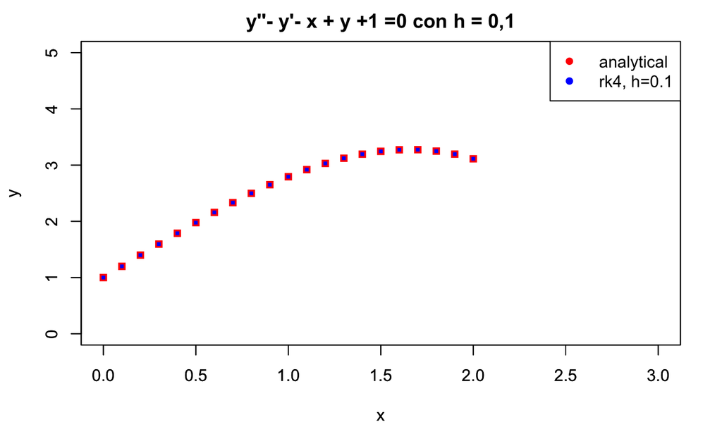

```r
sol = ode(c(1,2),tis,funcion,parms=NULL,method = "rk4")
tabla = data.frame(sol)
plot(tis,tabla[,2], pch = 15, col = "blue", cex = 0.5,xlim = c(0, 3), ylim = c(0, 5), xlab = "x", ylab = "y")
legend("topright",
       c("analytical","rk4, h=0.1"),
       lty = c(NA, NA), lwd = c(2, 1),
       pch = c(16, 16),
       col = c("red", "blue"))
```

```r
error <- (yR-tabla[,2])/tabla[,2]
tablaError = data.frame(tis, round(yR, digits = 5),round(tabla[,2], digits = 5),round(error, digits = 5))
colnames(tablaError) <- c("x","y()","y(RK4)","Error")
tablaError
```

| x | y() | y(RK4) | Error |
| --- | --- | --- | --- |
| 0.0 | 1.000 | 1.000 | 0 |
| 0.1 | 1.200 | 1.200 | 0 |
| 0.2 | 1.399 | 1.399 | 0 |
| 0.3 | 1.595 | 1.595 | 0 |
| 0.4 | 1.788 | 1.788 | 0 |
| 0.5 | 1.977 | 1.977 | 0 |
| 0.6 | 2.159 | 2.159 | 0 |
| 0.7 | 2.333 | 2.333 | 0 |
| 0.8 | 2.498 | 2.498 | 0 |
| 0.9 | 2.652 | 2.652 | 0 |

[output cut: 11 more lines]

```r
errorGlobal <- sum(error)/length(error)
errorGlobal
```

```
[1] 5.3039e-07
```

Punto 4. Utilizando el método de Euler mejorado y el método de Taylor, solucionar el siguiente problema: Una masa de c libras de peso,está unida al extremo libre de un resorte ligero que es estirado 1 pie por una fuerza de 4 libras. La masa se encuentra inicialmente en reposo en su posición de equilibrio. Iniciando en el tiempo t = 0 (segundos), se le aplica una fuerza externa f(t) = cos2t a la masa, pero en el instante t = 2π la fuerza se interrumpe (abruptamente ) y la masa queda libre continuando con su movimiento. Encuéntrese la función x(t) de posición resultante para la masa, gráfique la función de movimiento, encuentre en el periodo, la frecuencia, y en que instantes pasa por su posición de equilibrio.

```
        t        y
 [1,] 4.0  0.00000
 [2,] 4.1 -0.01455
 [3,] 4.2 -0.04739
 [4,] 4.3 -0.09419
 [5,] 4.4 -0.14938
 [6,] 4.5 -0.20768
 [7,] 4.6 -0.26505
 [8,] 4.7 -0.31904
 [9,] 4.8 -0.36852
[10,] 4.9 -0.41316
```

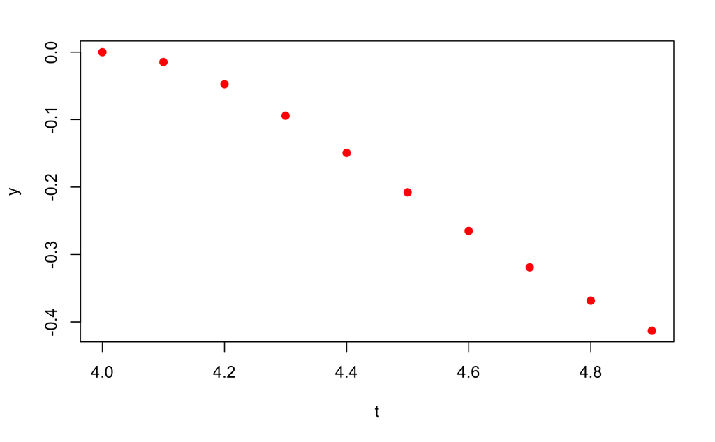

```r
euler1 = function(f, t0, y0, h, n) {
#Datos igualmente espaciados iniciando en x0 = a, paso h. "n" datos
t = seq(t0, t0 + (n-1)*h, by = h) # n datos
y = rep(NA, times=n) # n datos
y[1]=y0
for(i in 2:n ) y[i]= y[i-1]+h*f(t[i-1], y[i-1])
print(cbind(t,y)) # print
plot(t,y, pch=19, col="red") # gráfica
}
f = function(t,u) cos(2*t)-u*(t-2*pi)*cos(2*(t-2*pi))
euler1(f, 4, 0, 0.1, 10)
```

```
        t        y
 [1,] 4.0  0.00000
 [2,] 4.1 -0.02424
 [3,] 4.2 -0.06490
 [4,] 4.3 -0.11686
 [5,] 4.4 -0.17455
 [6,] 4.5 -0.23320
 [7,] 4.6 -0.28954
 [8,] 4.7 -0.34179
 [9,] 4.8 -0.38925
[10,] 4.9 -0.43183
```

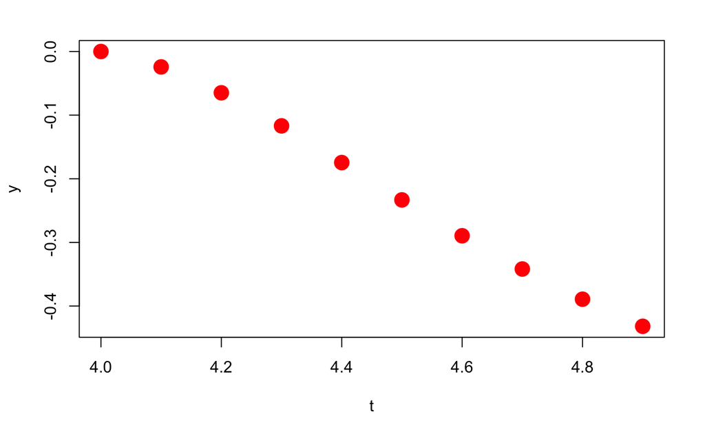

```r
#install.packages(Deriv)
require(Deriv) # derivadas parciales
#--- Metodo de Taylor, orden 4
mtaylor4 = function(f, t0, y0, h, n){
#Datos igualmente espaciados iniciando en t0 = a, paso h. "n" datos
t = seq(t0, t0 + (n-1)*h, by = h) # n datos
y = rep(NA, times=n) # n datos
y[1] = y0
  # Derivadas parciales con el paquete Deriv. Deriv(f)
ft=Deriv(f,"t"); fy=Deriv(f,"y")
f1 = function(t,y)
ft(t,y)+fy(t,y)*f(t,y)
f1t=Deriv(f1,"t");   f1y=Deriv(f1,"y")
f2= function(t,y) f1t(t,y)+f1y(t,y)*f(t,y)
f2t=Deriv(f2,"t");    f2y=Deriv(f2,"y")
f3= function(t,y) f2t(t,y)+f2y(t,y)*f(t,y)
for(i in 2:n ){
# orden m = 4
     f0i = f(t[i-1], y[i-1])
     f1i = f1(t[i-1], y[i-1])
     f2i = f2(t[i-1], y[i-1])
     f3i = f2(t[i-1], y[i-1])
     y[i] = y[i-1] + h*(f0i + h/2*f1i + h^2/6*f2i + h^3/24*f3i )
  }
  print(cbind(t,y))                   #imprimir
  plot(t,y, pch=19, col="red",cex = 2) #gráfica
}
f = function(t,u)  cos(2*t)-u*(t-2*pi)*cos(2*(t-2*pi))
 t0 = 4; y0 = 0; h = 0.1; n=10
 mtaylor4(f, t0, y0, h, n)
```

Punto 5. Utilizando la ecuación del problema uno verifique la sensibilidad y la estabilidad del método.

```r
funcionReal<-function(x){
  yR <- (2/15)*exp(x/2)*(15*cos((sqrt(15)*x)/2)-2*sqrt(15)*sin((sqrt(15)*x)/2))
  return(yR)
}
funcion=function(t,y,parms){
  dy <- y[2]
  dz <- -4*y[1]+y[2]
  return(list(c(dy,dz)))
}
tis = seq(0,2,by = 0.1)
yR = funcionReal(tis)
plot(tis,yR,pch = 15, col = "red", cex = 1, xlim = c(0, 2), ylim = c(-10, 5), xlab = "x", ylab = "y",main = "x''-x-x'=0 con h = 0,1")
par(new = TRUE)
```

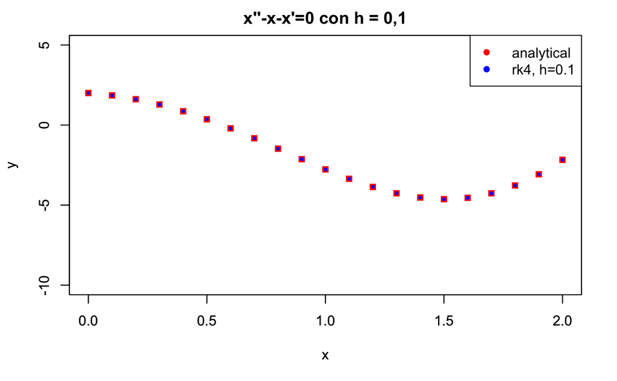

```r
sol = ode(c(2,-1),tis,funcion,parms=NULL,method = "rk4")
tabla = data.frame(sol)
plot(tis,tabla[,2], pch = 15, col = "blue", cex = 0.5,xlim = c(0, 2), ylim = c(-10, 5), xlab = "x", ylab = "y")
legend("topright",
       c("analytical","rk4, h=0.1"),
       lty = c(NA, NA), lwd = c(2, 1),
       pch = c(16, 16),
       col = c("red", "blue"))
```

```r
error <- (yR-tabla[,2])/tabla[,2]
tablaError = data.frame(tis, round(yR, digits = 5),round(tabla[,2], digits = 5),round(error, digits = 5))
vp<-0
fn<-0
for(i in 1:10){
  if(tablaError[i,3]<0.00001){
    vp=vp+1
  }else{
    fn=fn+1
  }
}
sencibilidad = vp/(vp+fn)
print(vp)
```

```
[1] 4
```

```r
print(fn)
```

```
[1] 6
```

```r
print(sencibilidad)
```

```
[1] 0.4
```

```r
#print ("La sencibilidad del método es de ", sencibilidad, "con VP=",vp, "y fn=",fn)
#lambda<<0
#Suponinedo que lambda es -100
estabilidad<-function(z){
  1+z
}
Z<-function(h,lambda){
  h+lambda
}
h=0.1
lambda=-100
estabilidad(Z(h,lambda))
```

```
[1] -98.9
```

Punto 6. Construya métoodo numérico para solucionar el problema conocido de deflexion de una viga.

```r
defleccion <- function(L,q,E,S,I){ S/(E*I)*w + q*x/(2*E*I)+(x-L)}
defleccion <- function(L,q,E,S,I,x){ S/(E*I)*w + q*x/(2*E*I)+(x-L)}
```

Punto 7. Implemente un método numérico que permita solucionar una ecuación diferencial, teniendo como información adicional tres puntos de la solución.

```r
require(mosaicCalc)
# 5x'' + 33x' + x - 5 = 0
# x''(0) = 2
# x'(0) = 1
# x(0) = 0
sol <- integrateODE(dx~ 5*x2 + 33*x1 + x - 5, x2=2, x1=1, x = 0, xdur=list(from=0,to=50)  )
print(sol$x(1))
```

```
[1] 65.29
```

Punto 8. Resolver el sistema homogeneo utilizando el método de Runge-Kutta, compare con la solución exacta, calcule el tamaño del error:

```
        t        y
 [1,] 0.0  0.00000
 [2,] 0.1  0.01911
 [3,] 0.2  0.10095
 [4,] 0.3  0.30900
 [5,] 0.4  0.77100
 [6,] 0.5  1.74402
 [7,] 0.6  3.74526
 [8,] 0.7  7.81550
 [9,] 0.8 16.04888
[10,] 0.9 32.65922
[11,] 1.0 66.12546
```

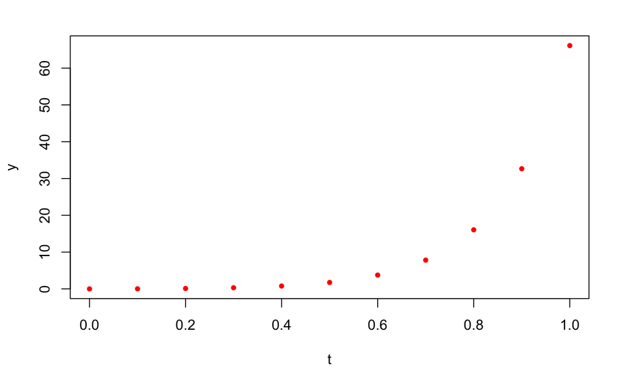

```r
rungekutta = function(f,t0,y0,h,n){
t = seq(t0, t0+n*h, by=h)
y = rep(NA, times=(n+1))
# length(t)==length(y)
y[1] = y0
for(k in 2:(n+1)){
  k1=h/2*f(t[k-1],y[k-1])
  k2=h/2*f(t[k-1]+h/2, y[k-1]+k1)
  k3=h/2*f(t[k-1]+h/2, y[k-1]+k2)
  k4=h/2*f(t[k-1]+h, y[k-1]+2*k3)
  y[k] = y[k-1]+1/3*(k1+2*k2+2*k3+k4)
}
dat = cbind(t,y)
print(as.matrix(dat))
 plot(t,y,pch=20, col="red")
}
#Pruebas----
options(digits = 4)
f=function(x,y) 3*x+7*y
t0=0; y0=0; h= 0.1; n= 10
rungekutta(f,t0,y0,h,n)
```

```
        t        y
 [1,] 0.0 0.000000
 [2,] 0.1 0.005301
 [3,] 0.2 0.022523
 [4,] 0.3 0.053920
 [5,] 0.4 0.102172
 [6,] 0.5 0.170468
 [7,] 0.6 0.262597
 [8,] 0.7 0.383067
 [9,] 0.8 0.537236
[10,] 0.9 0.731479
[11,] 1.0 0.973373
```

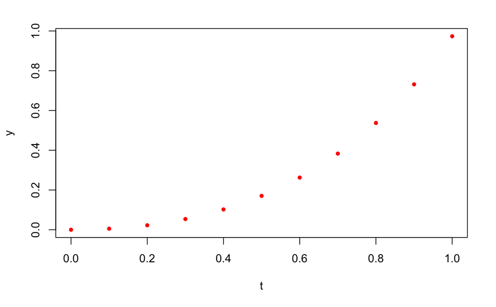

```r
f2f=function(x,y) x+sqrt(3)*y
rungekutta(f2f,t0,y0,h,n)
```

```r
exacta1=function(t) {
  1/sqrt(3+sqrt(3))*(-exp((4-sqrt(3*(3+sqrt(3)))*t))+sqrt(3)*exp((4-sqrt(3*(3+sqrt(3)))*t))+sqrt(3+sqrt(3))*exp((4-sqrt(3*(3+sqrt(3)))*t))+exp((4+sqrt(3*(3+sqrt(3)))*t))-sqrt(3)*exp((4+sqrt(3*(3+sqrt(3)))*t))+sqrt(3+sqrt(3))*exp((4+sqrt(3*(3+sqrt(3)))*t)))
}
exacta2= function(t){
  1/sqrt(3*(3+sqrt(3)))*(-6*exp(4-sqrt(3*(3+sqrt(3))))+sqrt(3*(3+sqrt(3)))*exp(4-sqrt(3*(3+sqrt(3))))+6*exp(4+sqrt(3*(3+sqrt(3))))+sqrt(3*(3+sqrt(3)))*exp(4+sqrt(3*(3+sqrt(3)))))
}
```

Se utilizarón las siguientes paginas como guía: https://rdrr.io/cran/mosaicCalc/src/R/integrateODE.R http://canek.azc.uam.mx/Ecuaciones/Teoria/6.Laplace/6.6.Aplicaciones/S2x/FD28.pdf http://wmatem.eis.uva.es/~jesroj/matem1/Curso/Cap08a_Esquema.pdf